# Preparing Your Computer for SNA

Douglas Luke

July 8, 2019

# Introduction

There are only a few things that need to be done to set up a computer for the Social Network Analysis workshop. Assuming you have a reasonably new laptop with a fairly modern operating system, these steps should take you less than 15 minutes. Specifically, you should do four things to prepare your computer:

1. Download and install R
2. Download and install RStudio
3. Within RStudio, install two network packages
4. Within RStudio, install the UserNetR dataset package

You may already have R and RStudio installed on your computer as part of a previous class or work that you do. In that case, you can skip the first two steps, but make sure you have the most recent versions of both R and RStudio installed.

# Setting up *R*

- Go to http://cran.r-project.org.
- Navigate to where you can download the appropriate version for your operating system.
- Download and install the current build (3.6.1, currently).
- (If installing under Windows, may want to install as the administrator to avoid some potential problems down the road.)
- Run to make sure that it is installed properly.
- You can type in the following commands just to make sure that it is working correctly.

```r
dum <- 1:10
dum2 <- dum^2
dum
```

```
##  [1]  1  2  3  4  5  6  7  8  9 10
```

```r
dum2
```

```
##  [1]   1   4   9  16  25  36  49  64  81 100
```

## Installing *RStudio* IDE for *R*

- Download RStudio from https://www.rstudio.com/products/rstudio.
- The current version is 1.2.1335. You want the desktop version, not the server version.
- When you install it should automatically detect your *R* installation.

## Installing required network packages

The basic functionality of R can be extended by using various packages. These are created by other statisticians and scientists, and are free to install and use. For this class we will be using two different network analysis packages: *statnet* and *igraph*. For the following code (and all coding we will do in this class), this will be run within the RStudio IDE. If you are new to R/RStudio, just type each code line into the RStudio console window.

The following code will install the two network packages.

```r
install.packages("statnet")
install.packages("igraph")
```

## Installing the *UserNetR* package

I have created and collected a number of example datasets that accompany my Springer book, and these will be used in this class. They are available as an R package, which can be downloaded and installed within R itself.

- Start RStudio, and make sure it is working properly.
- Install the *devtools* package by typing in the following line of code in the console (by default, the window in the lower left-hand corner):

```r
install.packages("devtools")
```

- Assuming this worked with no errors, then type in the following code to install the *UserNetR* package:

```r
library(devtools)
install_github("DougLuke/UserNetR")
```

# Testing everything

- The following code should then work to access one of the datasets, present some basic information about the network, and plot the network. The network plot itself may look a bit different when you plot.

```r
library(statnet)
library(UserNetR)
data(Moreno)
summary(Moreno,print.adj=FALSE)
```

```
## Network attributes:
##   vertices = 33
##   directed = FALSE
##   hyper = FALSE
##   loops = FALSE
##   multiple = FALSE
##   bipartite = FALSE
##  total edges = 46
##    missing edges = 0
##    non-missing edges = 46
##  density = 0.08712121
##
## Vertex attributes:
##
##  gender:
##    numeric valued attribute
##    attribute summary:
##    Min. 1st Qu.  Median    Mean 3rd Qu.    Max.
##   1.000   1.000   2.000   1.515   2.000   2.000
##   vertex.names:
##    character valued attribute
##    33 valid vertex names
##
## No edge attributes
```

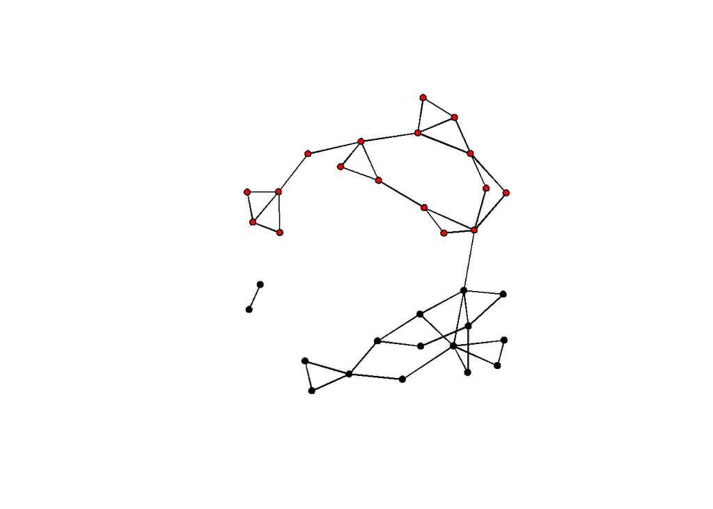

```r
plot(Moreno, vertex.col = "gender")
```